# survival lecture 7

Steve Simon

May 27, 2018

Lecture 7. Frailty models. You can incorporate mutliple events per patient and account for center effects using frailty models, the survival data analysis equivalent to mixed models in linear regression. You’ll see how to define random effects and how to fit and interpret these models.

This file does not need any special libraries other than the ones listed below. Many of the data sets in this program use data from Hosmer, Lemeshow, and May. I made one minor change, however, which was to force all the variable names to lower case.

```r
library(broom)
library(coxme)
library(dplyr)
```

```r
library(ggplot2)
library(magrittr)
library(survival)
library(tidyr)
```

## Psychiatric dataset

This data set can be found at

math.usu.edu/jrstevens/biostat/projects2013/pres_LeftTruncation.pdf

It illustrates an application of left truncation.

```r
par(mar=c(2.6, 2.6, 0.6, 0.6), las=1)
fn <- "~/survival-models/bin/psychiatric.RData"
load(fn)

head(psychiatric)
```

```
##      sex age time  death age2
## 1 female  51    1  death   52
## 2 female  58    1  death   59
## 3 female  55    2  death   57
## 4 female  28   22  death   50
## 5   male  21   30 censor   51
## 6   male  19   28  death   47
```

```r
table(psychiatric$sex)
```

```
##
##   male female
##     10     15
```

```r
table(psychiatric$death)
```

```
##
## censor  death
##     11     14
```

```r
summary(psychiatric$age)
```

```
##    Min. 1st Qu.  Median    Mean 3rd Qu.    Max.
##   19.00   29.00   33.00   35.56   43.00   58.00
```

```r
summary(psychiatric$age2)
```

```
##    Min. 1st Qu.  Median    Mean 3rd Qu.    Max.
##   47.00   57.00   61.00   61.72   67.00   76.00
```

```r
summary(psychiatric$age2-psychiatric$age)
```

```
##    Min. 1st Qu.  Median    Mean 3rd Qu.    Max.
##    1.00   22.00   30.00   26.16   35.00   40.00
```

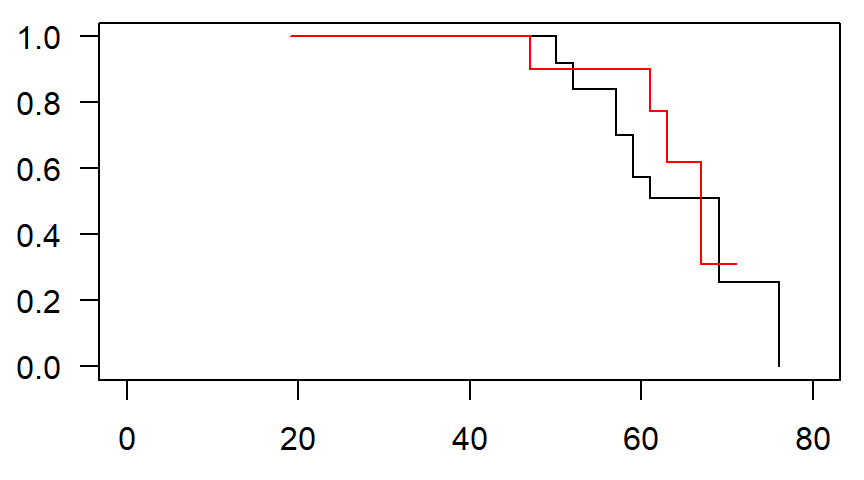

```r
psychiatric              %$%
  Surv(age, age2, death=="death") -> psychiatric_surv
survfit(psychiatric_surv~psychiatric$sex)    %>%
  tidy                                       -> psychiatric_km
m <- psychiatric_km$strata=="psychiatric$sex=male"
f <- psychiatric_km$strata=="psychiatric$sex=female"

# Males are the red line, females black.
plot(c(0, 80), c(0, 1), type="n")
lines(
  psychiatric_km$time[f],
  psychiatric_km$estimate[f],
  type="s")
lines(
  psychiatric_km$time[m],
  psychiatric_km$estimate[m],
  type="s", col="red")
```

## Examples

The asaur package has all the data sets using in the book Applied Survival Analysis Using R, by Dirk F. Moore.

```r
# This dataset is found in the asaur package.
par(mar=c(2.6, 2.6, 0.6, 0.6))
library(asaur)
head(ashkenazi)
```

```
##   famID brcancer age mutant
## 1     1        0  73      0
## 2     1        0  40      0
## 3     7        0  48      0
## 4     7        0  25      0
## 5     8        0  56      0
## 6     8        0  55      0
```

```r
table(table(ashkenazi$famID))
```

```
##
##    2
## 1960
```

```r
table(ashkenazi$brcancer)
```

```
##
##    0    1
## 3447  473
```

```r
table(ashkenazi$mutant)
```

```
##
##    0    1
## 3830   90
```

```r
summary(ashkenazi$age)
```

```
##    Min. 1st Qu.  Median    Mean 3rd Qu.    Max.
##    1.00   45.00   59.00   58.63   73.00  100.00
```

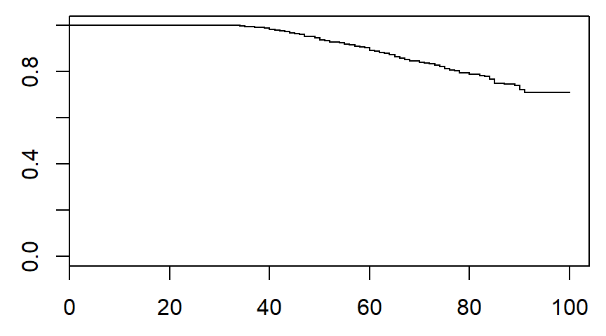

```r
bc_surv <- Surv(ashkenazi$age, ashkenazi$brcancer)
km_overall <- survfit(bc_surv~1)
plot(km_overall, conf.int=FALSE)
```

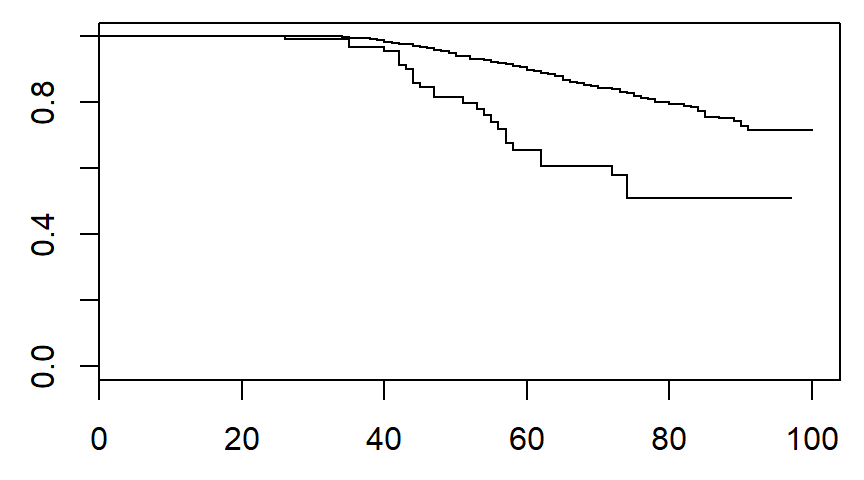

```r
km_mutant <- survfit(bc_surv~ashkenazi$mutant)
plot(km_mutant)
```

```r
coxph(bc_surv~mutant+cluster(famID), data=ashkenazi)
```

```
## Call:
## coxph(formula = bc_surv ~ mutant + cluster(famID), data = ashkenazi)
##
##         coef exp(coef) se(coef) robust se    z     p
## mutant 1.191     3.290    0.198     0.202 5.89 4e-09
##
## Likelihood ratio test=25.9  on 1 df, p=3.55e-07
## n= 3920, number of events= 473
```

```r
ashkenazi_random <- coxph(
  bc_surv~mutant+frailty(famID),
  data=ashkenazi)
ashkenazi_random
```

```
## Call:
## coxph(formula = bc_surv ~ mutant + frailty(famID), data = ashkenazi)
##
##                   coef se(coef)     se2   Chisq  DF     p
## mutant           1.272    0.232   0.200  30.134   1 4e-08
## frailty(famID)                          221.500 212  0.31
##
## Iterations: 6 outer, 26 Newton-Raphson
##      Variance of random effect= 0.494   I-likelihood = -3564.3
## Degrees of freedom for terms=   0.7 211.6
## Likelihood ratio test=400  on 212 df, p=1.17e-13  n= 3920
```

```r
# This data set is found in the survival package.
par(mar=c(2.6, 2.6, 0.6, 0.6))
head(rats)
```

```
##   litter rx time status sex
## 1      1  1  101      0   f
## 2      1  0   49      1   f
## 3      1  0  104      0   f
## 4      2  1   91      0   m
## 5      2  0  104      0   m
## 6      2  0  102      0   m
```

```r
table(rats$rx)
```

```
##
##   0   1
## 200 100
```

```r
table(rats$status)
```

```
##
##   0   1
## 258  42
```

```r
table(rats$sex)
```

```
##
##   f   m
## 150 150
```

```r
summary(rats$time)
```

```
##    Min. 1st Qu.  Median    Mean 3rd Qu.    Max.
##   23.00   80.75   98.00   90.44  104.00  104.00
```

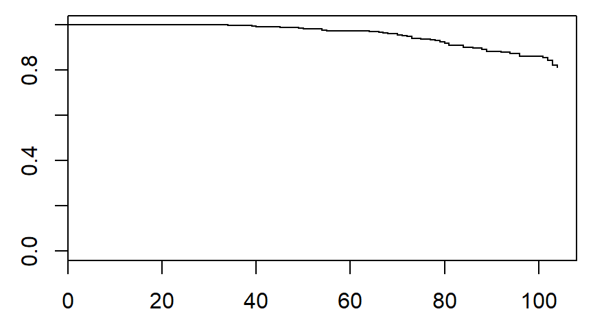

```r
rats_surv <- Surv(rats$time, rats$status)
overall_km <- survfit(rats_surv~1)
plot(overall_km, conf.int=FALSE)
```

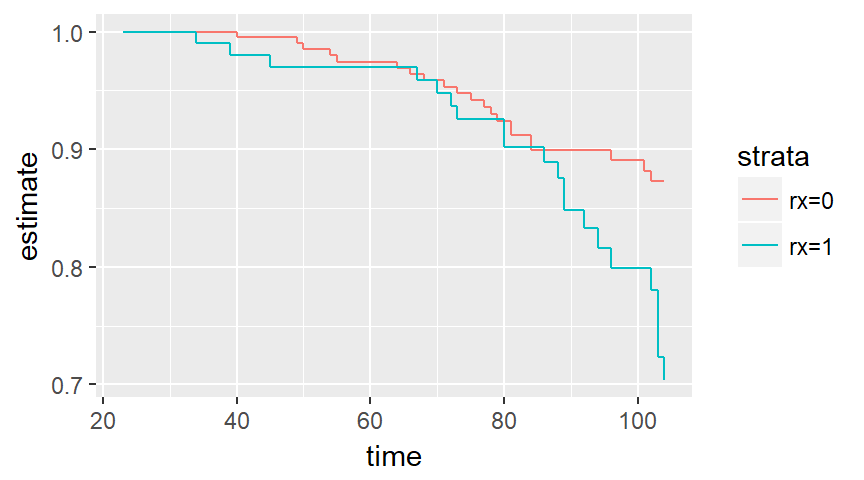

```r
survfit(rats_surv~rx, data=rats)           %>%
  tidy                                     %>%
  ggplot(aes(time, estimate, color=strata)) +
    geom_step()
```

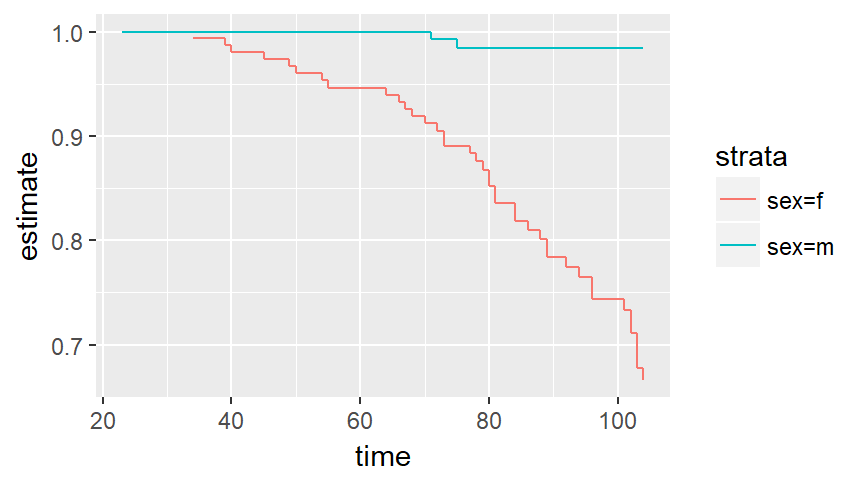

```r
survfit(rats_surv~sex, data=rats)          %>%
  tidy                                     %>%
  ggplot(aes(time, estimate, color=strata)) +
    geom_step()
```

```r
coxph(
  rats_surv~rx+cluster(litter),
  data=rats,
  subset=(sex=="f"))
```

```
## Call:
## coxph(formula = rats_surv ~ rx + cluster(litter), data = rats,
##     subset = (sex == "f"))
##
##     coef exp(coef) se(coef) robust se    z      p
## rx 0.905     2.471    0.318     0.303 2.99 0.0028
##
## Likelihood ratio test=7.98  on 1 df, p=0.00474
## n= 150, number of events= 40
```

```r
rats_random <- coxph(
  rats_surv~rx+frailty(litter),
  data=rats,
  subset=(sex=="f"))
rats_random
```

```
## Call:
## coxph(formula = rats_surv ~ rx + frailty(litter), data = rats,
##     subset = (sex == "f"))
##
##                   coef se(coef)    se2  Chisq   DF      p
## rx               0.914    0.323  0.319  8.012  1.0 0.0046
## frailty(litter)                        17.692 14.4 0.2443
##
## Iterations: 6 outer, 24 Newton-Raphson
##      Variance of random effect= 0.499   I-likelihood = -180.8
## Degrees of freedom for terms=  1.0 14.4
## Likelihood ratio test=37.6  on 15.4 df, p=0.00124  n= 150
```

```r
par(mar=c(2.6, 2.6, 0.6, 0.6))
# This data set is found in the timereg package.
library(timereg)
data(diabetes)
head(diabetes)
```

```
##   id     time status trteye treat adult agedx
## 1  5 46.24967      0      2     1     2    28
## 2  5 46.27553      0      2     0     2    28
## 3 14 42.50684      0      1     1     1    12
## 4 14 31.34145      1      1     0     1    12
## 5 16 42.30098      0      1     1     1     9
## 6 16 42.27406      0      1     0     1     9
```

```r
table(table(diabetes$id))
```

```
##
##   2
## 197
```

```r
summary(diabetes$time)
```

```
##    Min. 1st Qu.  Median    Mean 3rd Qu.    Max.
##  0.3154 13.9851 38.8293 35.6105 54.2951 75.0260
```

```r
table(diabetes$status)
```

```
##
##   0   1
## 239 155
```

```r
table(diabetes$trteye)
```

```
##
##   1   2
## 178 216
```

```r
table(diabetes$treat)
```

```
##
##   0   1
## 197 197
```

```r
table(diabetes$adult)
```

```
##
##   1   2
## 228 166
```

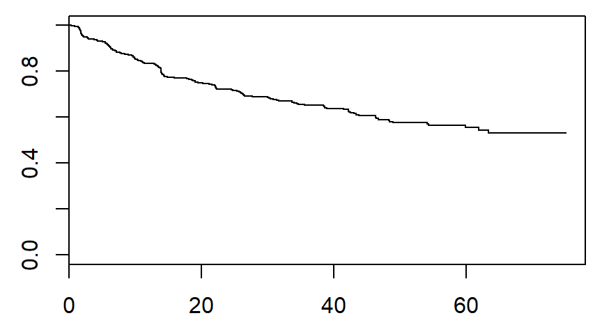

```r
diabetes_surv <- Surv(diabetes$time, diabetes$status)
km_overall <- survfit(diabetes_surv~1)
plot(km_overall, conf.int=FALSE)
```

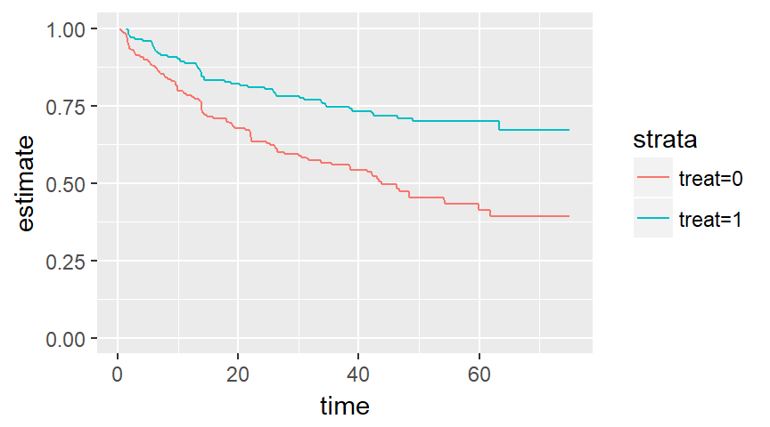

```r
survfit(diabetes_surv~treat, data=diabetes) %>%
  tidy                                      %>%
  ggplot(aes(time, estimate, color=strata))  +
  expand_limits(y=0)                         +
  geom_step()
```

```r
coxph(
  diabetes_surv~treat+agedx+cluster(id),
  data=diabetes)
```

```
## Call:
## coxph(formula = diabetes_surv ~ treat + agedx + cluster(id),
##     data = diabetes)
##
##           coef exp(coef) se(coef) robust se     z       p
## treat -0.78216   0.45742  0.16897   0.14834 -5.27 1.3e-07
## agedx  0.00403   1.00404  0.00547   0.00626  0.64    0.52
##
## Likelihood ratio test=22.9  on 2 df, p=1.06e-05
## n= 394, number of events= 155
```

```r
coxph(
  diabetes_surv~treat+agedx+frailty(id),
  data=diabetes)
```

```
## Call:
## coxph(formula = diabetes_surv ~ treat + agedx + frailty(id),
##     data = diabetes)
##
##                  coef  se(coef)       se2     Chisq DF       p
## treat        -0.91642   0.17445   0.17136  27.59594  1 1.5e-07
## agedx         0.00542   0.00747   0.00565   0.52783  1   0.468
## frailty(id)                               113.86639 84   0.017
##
## Iterations: 6 outer, 30 Newton-Raphson
##      Variance of random effect= 0.851   I-likelihood = -850.6
## Degrees of freedom for terms=  1.0  0.6 84.0
## Likelihood ratio test=202  on 85.5 df, p=2.37e-11  n= 394
```

The kidney data set contains information on catheter infections, and is available within the survival package of R.

```r
par(mar=c(2.6, 2.6, 0.6, 0.6))
head(kidney)
```

```
##   id time status age sex disease frail
## 1  1    8      1  28   1   Other   2.3
## 2  1   16      1  28   1   Other   2.3
## 3  2   23      1  48   2      GN   1.9
## 4  2   13      0  48   2      GN   1.9
## 5  3   22      1  32   1   Other   1.2
## 6  3   28      1  32   1   Other   1.2
```

```r
table(table(kidney$id))
```

```
##
##  2
## 38
```

```r
table(kidney$status)
```

```
##
##  0  1
## 18 58
```

```r
table(kidney$sex)
```

```
##
##  1  2
## 20 56
```

```r
table(kidney$disease)
```

```
##
## Other    GN    AN   PKD
##    26    18    24     8
```

```r
summary(kidney$time)
```

```
##    Min. 1st Qu.  Median    Mean 3rd Qu.    Max.
##     2.0    16.0    39.5   101.6   149.8   562.0
```

```r
summary(kidney$age)
```

```
##    Min. 1st Qu.  Median    Mean 3rd Qu.    Max.
##    10.0    34.0    45.5    43.7    54.0    69.0
```

```r
summary(kidney$frail)
```

```
##    Min. 1st Qu.  Median    Mean 3rd Qu.    Max.
##   0.200   0.600   1.100   1.184   1.500   3.000
```

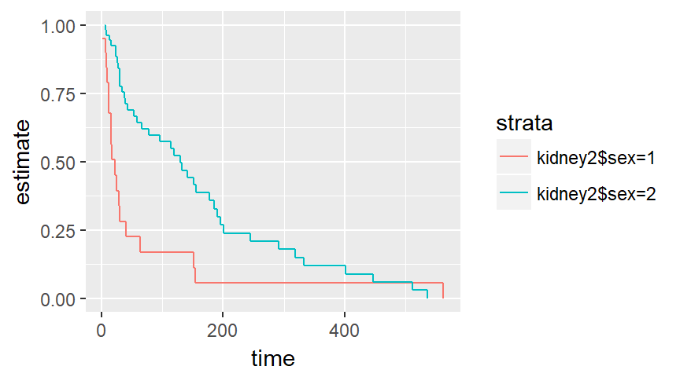

```r
kidney2 <- kidney
kidney2$s <- rep(1:2, 38)

kidney_surv <- Surv(kidney2$time, kidney2$status)
survfit(kidney_surv~kidney2$sex)     %>%
  tidy                               %>%
  ggplot(aes(time, estimate, color=strata)) +
  geom_step()
```

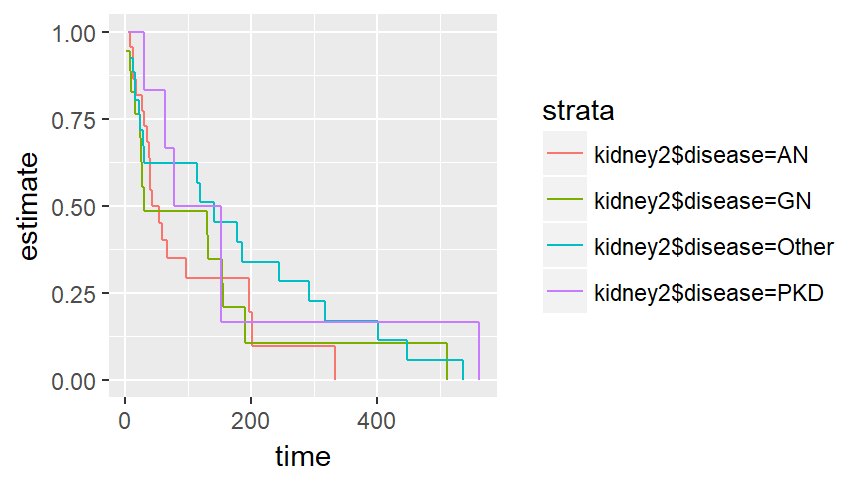

```r
survfit(kidney_surv~kidney2$disease) %>%
  tidy                               %>%
  ggplot(aes(time, estimate, color=strata)) +
  geom_step()
```

```r
coxph(
  kidney_surv~age+sex+disease+cluster(id),
  data=kidney2)
```

```
## Call:
## coxph(formula = kidney_surv ~ age + sex + disease + cluster(id),
##     data = kidney2)
##
##                coef exp(coef) se(coef) robust se     z       p
## age         0.00318   1.00319  0.01115   0.00719  0.44 0.65842
## sex        -1.48314   0.22692  0.35823   0.40085 -3.70 0.00022
## diseaseGN   0.08796   1.09194  0.40637   0.28699  0.31 0.75924
## diseaseAN   0.35079   1.42020  0.39972   0.27497  1.28 0.20204
## diseasePKD -1.43111   0.23904  0.63111   0.87132 -1.64 0.10050
##
## Likelihood ratio test=17.6  on 5 df, p=0.00342
## n= 76, number of events= 58
```

```r
coxph(
  kidney_surv~age+sex+disease+frailty(id),
  data=kidney2)
```

```
## Call:
## coxph(formula = kidney_surv ~ age + sex + disease + frailty(id),
##     data = kidney2)
##
##                  coef  se(coef)       se2     Chisq DF       p
## age          3.18e-03  1.11e-02  1.11e-02  8.14e-02  1   0.775
## sex         -1.48e+00  3.58e-01  3.58e-01  1.71e+01  1 3.5e-05
## diseaseGN    8.80e-02  4.06e-01  4.06e-01  4.68e-02  1   0.829
## diseaseAN    3.51e-01  4.00e-01  4.00e-01  7.70e-01  1   0.380
## diseasePKD  -1.43e+00  6.31e-01  6.31e-01  5.14e+00  1   0.023
## frailty(id)                                2.71e-05  0   0.933
##
## Iterations: 6 outer, 35 Newton-Raphson
##      Variance of random effect= 5e-07   I-likelihood = -179.1
## Degrees of freedom for terms= 1 1 3 0
## Likelihood ratio test=17.6  on 5 df, p=0.00342  n= 76
```

Save everything for possible later re-use.

```r
save.image("~/survival-models/bin/survival-lecture-7.RData")
```